# Handout W01 — Pytanie, pomiar i projekt

Zarządzanie informacją — mapa wykładu i pytania do notatek

Marek Deja

2026/27

# Problem, do którego wracamy

Biblioteka otrzymuje sygnały, że trudno znaleźć dokument w katalogu. Rozważa zmianę filtrów, film instruktażowy lub szkolenie. Wybór rozwiązania wymaga rozpoznania bariery: interfejsu, przygotowania użytkownika, zadania albo dostępności informacji. Zbiór S02 (S — scenariusz danych kursu) jest syntetycznym przykładem ankiety po zadaniu połączonej z obserwacją czasu i powodzenia; zawiera 150 rekordów i służy do ćwiczenia analizy.

Kody jednostek: W01–W05 to wykłady, C01–C10 ćwiczenia, a Z01–Z10 zadania oddawane po ćwiczeniach o tych samych numerach. Wykres „Sześć etapów rozumowania” podaje kolejność pracy od problemu do wniosku wraz z pytaniem na każdym etapie.

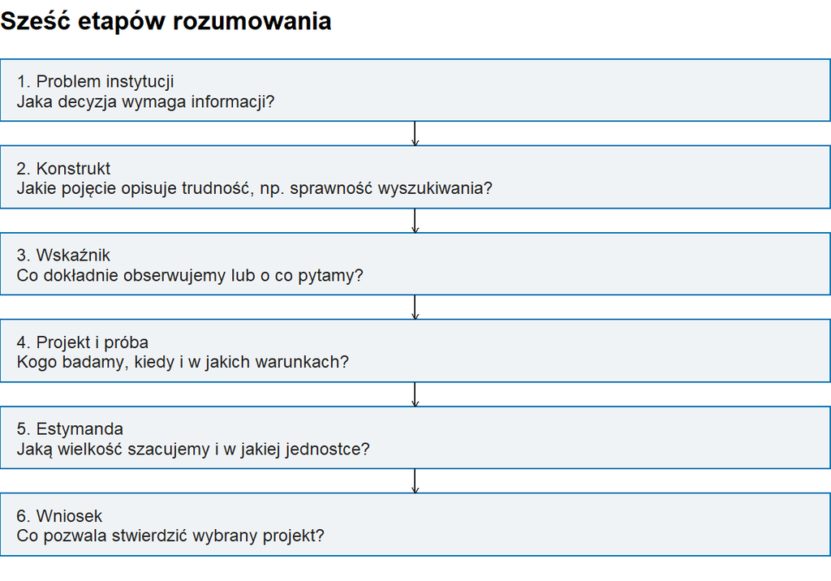

Sześć etapów rozumowania od problemu instytucji do wniosku, ułożonych od góry do dołu: problem, konstrukt, wskaźnik, projekt i próba, estymanda, wniosek; przy każdym etapie stoi pytanie do zapisania.

W S02 indeks sześciu pozycji opisuje deklarowaną użyteczność katalogu i radzenie sobie z katalogiem; pozycja 3 („Odczytanie rekordu wymaga ode mnie zgadywania.”) jest odwrócona wzorem $6-x$. Czas oraz powodzenie to wskaźniki wykonania konkretnego zadania. Zgodność deklaracji i wykonania jest pytaniem do zbadania.

# Język wzoru

$$\widehat{\Delta}=\bar{x}_N-\bar{x}_D.$$

Czytamy: „szacowana różnica to średni czas nowych minus średni czas doświadczonych użytkowników”. Dodatni wynik oznacza dłuższy czas nowych osób. Przy średnich 9 i 7 minut estymata różnicy wynosi 2 minuty.

| Pojęcie | Znaczenie w przykładzie |
| --- | --- |
| Estymanda | Różnica średnich czasów w określonej populacji i zadaniu |
| Parametry $\mu_N,\mu_D$ | Średnie populacyjne w grupach |
| Estymator $\bar{x}_N-\bar{x}_D$ | Reguła obliczenia różnicy z próby |
| Estymata $\widehat{\Delta}=2$ min | Liczba uzyskana z konkretnych danych |
| $n_N,n_D$ | Liczby ważnych obserwacji we właściwych grupach |

Zamiana grup zmienia znak. Przeliczenie minut na sekundy zmienia jednostkę i liczbową wartość różnicy, a relacja między grupami pozostaje ta sama. Pełny wynik zawiera także miarę niepewności. Wykres „Ta sama estymata, dwa przedziały” przedstawia różnicę 2 minut z przedziałem wąskim od 1,7 do 2,3 minuty i szerokim od −3 do 7 minut; tylko przedział wąski leży w całości po dodatniej stronie zera.

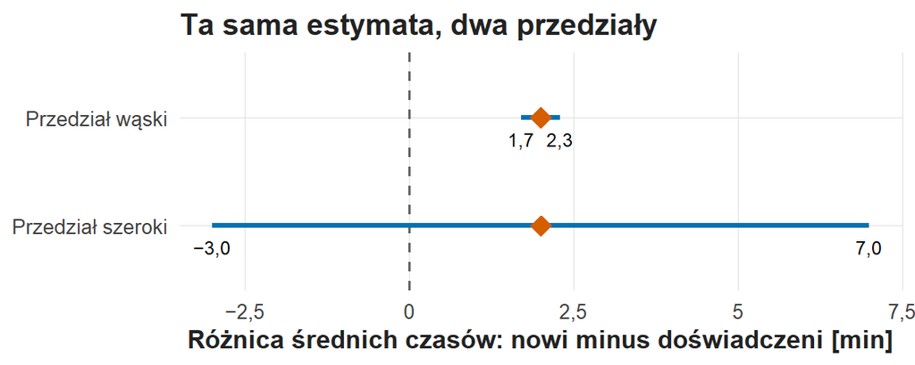

Ta sama estymata różnicy 2 minut z dwoma przedziałami. Przedział wąski obejmuje wartości od 1,7 do 2,3 minuty, przedział szeroki od −3 do 7 minut i przecina linię zera.

Notatka: jakie zdanie o nowych użytkownikach uzasadnia każdy z dwóch przedziałów?

# Projekty tej samej usługi

| Projekt | Przykład pytania | Zakres wniosku |
| --- | --- | --- |
| Opis | Jaki odsetek nowych osób znajduje dokument? | Opis próby lub określonej populacji przy uzasadnionym doborze |
| Porównanie obserwacyjne | O ile różnią się nowi i doświadczeni? | Związek; inne cechy grup współtworzą różnicę |
| Losowy przydział instrukcji | Czy udostępnienie instrukcji zmienia powodzenie? | Silniejsza podstawa wniosku przyczynowego o przydzielonej interwencji |
| Przed–po | Jak zmienił się czas tych samych osób? | Analiza różnic w parach; wprawa i zmiana warunków jako wyjaśnienia alternatywne |

Losowy dobór osób daje podstawę uogólnienia. Losowy przydział warunku daje podstawę porównania przyczynowego. Projekt może zawierać jedno z dwóch losowań albo oba.

Quasi-eksperyment porównuje zmianę bez losowego przydziału: w przykładzie dwóch filii różnica zmian wynosi $(7-10)-(7-8)=-2$ minuty. Odczyt przyczynowy wymaga uzasadnienia równoległych trendów i kontroli innych zmian w filiach. Eksperyment naturalny wykorzystuje przydział wynikający z warunków zewnętrznych; wartość porównania zależy od mechanizmu przydziału.

Piramida dowodów o skutkach interwencji układa od podstawy: opinię eksperta, opis przypadku, badanie porównawcze bez randomizacji, badanie z randomizacją i przegląd systematyczny z metaanalizą. Piramida wskazuje, gdzie szukać badań skutków interwencji, a ocena konkretnej publikacji obejmuje dodatkowo pomiar i raportowanie. Przegląd systematyczny ma jawną procedurę, a metaanaliza liczbowo łączy oszacowania. Na pytanie o lokalną częstość bariery najlepiej odpowiada aktualne badanie obserwacyjne.

# Kontrole, które poprzedzają test

Jedna osoba wykonująca cztery zadania daje cztery rekordy zależnych pomiarów jednej jednostki analizy. Wartość NA oznacza wynik nieznany, a niepowodzenie — wynik zaobserwowany. Średnia udanych prób opisuje inną wielkość niż średnia wszystkich prób. Konstrukt definiują treść pytań i protokół, a nazwa kolumny jest etykietą.

Przy czasach 2, 3, 3 i 20 minut średnia wynosi 7, a mediana 3 minuty. Wybór miary zależy od pytania: średnia opisuje przeciętny nakład czasu, mediana środek uporządkowanej grupy.

**Do omówienia:** „80% respondentów dobrze ocenia katalog, więc 80% studentów ma wysokie kompetencje”. Wskaż błąd dotyczący populacji oraz odrębny błąd pomiaru. Zapisz własną poprawioną wersję, podając licznik i mianownik.

**Do własnej powtórki:** zapisz jedno pytanie o usługę informacyjną, jego estymandę i jednostkę. Dopisz informację wymagającą nowych danych. Notatka służy powtórce; projekt indywidualny rozpoczyna się na ćwiczeniu C09.

**Generatywna SI:** pomoc w zrozumieniu pojęcia lub błędu kodu jest dopuszczalna, a interpretację piszesz samodzielnie. Wykorzystane fragmenty oznaczasz, a hasła, tokeny i dane osobowe pozostają poza narzędziem. Korzystanie z narzędzia jest dobrowolne. Zasady opierają się na [zarządzeniu UJ nr 115/2025](https://bip.uj.edu.pl/documents/1384597/159749054/zarz_115_2025.pdf).

# Lektury i notatki

Wilson (1999) pomaga odróżnić zachowanie informacyjne od wyszukiwania w systemie; Kuhlthau (1991) zwraca uwagę na moment pomiaru w procesie; Hargittai (2002) uzasadnia łączenie ankiety z obserwacją; Vial (2019) dostarcza perspektywy zmiany organizacyjnej. Pełne odnośniki zawiera wykład.

Notatka: jakie dwie różne przyczyny mogą dać taki sam długi czas wyszukiwania?

Notatka: jakiego dodatkowego pomiaru potrzebujesz, aby rozróżnić obie przyczyny?